# Gathering ancillary data of the Monterrey POC

Cristian Correa

2025-03-12

# Libraries

```r
rm(list=ls())
library(tidyr)
library(dplyr)
library(ggplot2)
library(ncdf4) # for *.nc files
library(raster)
# library(sp)
# library(sf)
# library(geodata)
library(ggmap)
library(viridis)
```

In this document and script, various data sources offering worldwide remote-sensing data were queried to retrieve physical and biogeochemical variables with potential predictive power for biodiversity.

Fisrt, the study area and sample sites from Nowinski *et al.* (2019)[^1] were imported and then, various data sources and variables were visualized, and extracted for the sampling sites.

The main output is a table of attributes of sapling sites populated with many new variables.

```r
setwd("/cloud/project/MontereyBay")
```

# Import data

## Import sample data (sample_data)

```r
sample_data <- read.delim(file = "Monterey_curated_metadata.tsv")


head(sample_data, n=3)
```

```
##   NCBI_SRA_Run_ID GOLD_Project_ID       Type         Assembly_Method
## 1      SRR7592212       Gp0266591 Metagenome SPAdes assembler 3.11.1
## 2      SRR7592225       Gp0266592 Metagenome SPAdes assembler 3.11.1
## 3      SRR7592226       Gp0266593 Metagenome SPAdes assembler 3.11.1
##   Collection_Date          Instrument
## 1      2016-10-04 Illumina HiSeq-2000
## 2      2016-11-16 Illumina HiSeq-2000
## 3      2016-11-09 Illumina HiSeq-2000
##                                                            JGI_Contigs_Link
## 1 https://genome.jgi.doe.gov/portal/1D_rmetaG_FD/1D_rmetaG_FD.download.html
## 2     https://genome.jgi.doe.gov/portal/2DmetaG_FD/2DmetaG_FD.download.html
## 3     https://genome.jgi.doe.gov/portal/3DmetaG_FD/3DmetaG_FD.download.html
##   JGI_Project_ID JGI_Sample_ID JGI_Sequencing_Project_ID
## 1        1174504        166736                   1174680
## 2        1174506        166737                   1174681
```

[output cut: 17 more lines]

## Define map extent (area of interest)

```r
# make_bbox(data = sample_data, lon = lon, lat = lat)
# extent <- extent(-92, -89, -1.55, 0.68)
```

### Sampling dates

```r
sample_data$SamplingDate <- as.Date(sample_data$Collection_Date)
```

Sampling was conducted between the following dates: 2016-09-26, 2016-11-16.

# Geographic coordinates

Identify unique sets of coordinates and average by site if necessary

```r
coords <- sample_data %>% summarise(lat = unique(lat), lon = unique(lon) )
coords
```

```
##      lat      lon
## 1 36.835 -121.901
```

This Monterey Bay data set has only one sampling site.

Check geographic coordinates and identify potential problems. It may be useful to plot and label the mean site_code of stationary monitoring stations (e.g., temporal sampling in the same bay). In addition, plot the original geographic coordinates, and connect with edges sites under the same site label (all coordinates under the same site label should be close to each other).

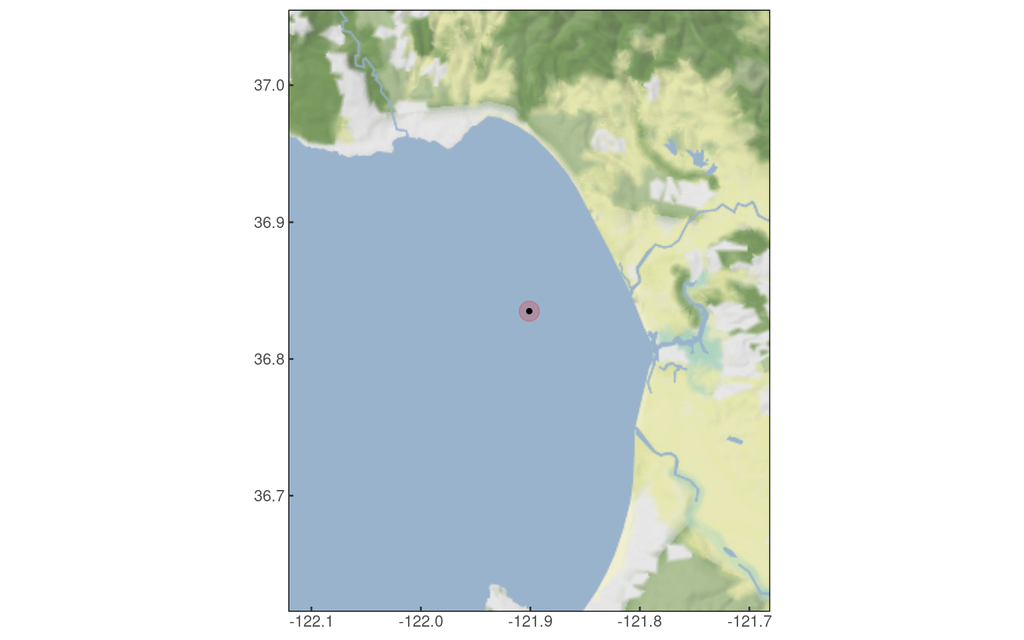

# Copernicus Marine Service

Copernicus Marine presents one of the largest data inventories of high-quality ocean data. The Copernicus Marine Service (or Copernicus Marine Environment Monitoring Service) is the marine component of the Copernicus Programme of the European Union. It provides free, regular and systematic authoritative information on the state of the Blue (physical), White (sea ice) and Green (biogeochemical) ocean, on a global and regional scale. It is funded by the European Commission (EC) and implemented by Mercator Ocean International https://data.marine.copernicus.eu/products.

There are a few options to download the data:

1. Downloaded using spatial, temporal, depth, etc., filters directly from the webpagehttps://data.marine.copernicus.eu/products. Then, the files can be further processed here.
2. There is a Phython API called `copernicusmarine` that can be used to mass-download data. See `Copernicus_data_download.py` for a script to download time series data in bulk. Once a folder is populated with all the necessary grid frames, continue processing over here.

## Net Primary Production

A time series was downloaded using the `Copernicus_data_download.py` script. Begin by examining one frame:

```r
# Set the path for the NetCDF file
ncfile <- "Monterrey_imagery_NPP/nppv_20161116.nc"

# # Import NetCDF
 nc <- nc_open(ncfile)

  print(nc)
```

```
## File Monterrey_imagery_NPP/nppv_20161116.nc (NC_FORMAT_NETCDF4):
##
##      1 variables (excluding dimension variables):
##         short npp[longitude,latitude,time]   (Contiguous storage)
##             _FillValue: -32767
##             standard_name: net_primary_productivity_of_biomass_expressed_as_carbon_in_sea_water
##             units: mg m-2 day-1
##             add_offset: 7846.3802682577
##             scale_factor: 0.239467138637724
##
##      3 dimensions:
##         time  Size:1
##             standard_name: time
##             axis: T
##             long_name: Time
##             unit_long: Seconds Since 1970-01-01
##             units: seconds since 1970-01-01
##             calendar: standard
##         latitude  Size:13
##             standard_name: latitude
##             axis: Y
##             units: degrees_north
##         longitude  Size:8
##             standard_name: longitude
##             axis: X
##             units: degrees_east
##
##     7 global attributes:
##         institution: CLS
##         history: Created on 2024-10-17
##         references: http://www.cls.fr; http://www.seapodym.eu
##         Conventions: CF-1.7
##         source: SEAPODYM-LMTL 3.0.0
##         title: Global ocean low and mid trophic levels biomass content hindcast
##         copernicusmarine_version: 2.0.1
```

Import the nc file as a raster

```r
library(raster)

# import NetCDF with raster
(npp <- raster("Monterrey_imagery_NPP/nppv_20161116.nc"))
```

```
## class      : RasterLayer
## dimensions : 13, 8, 104  (nrow, ncol, ncell)
## resolution : 0.08333261, 0.08333333  (x, y)
## extent     : -122.4583, -121.7917, 36.29167, 37.375  (xmin, xmax, ymin, ymax)
## crs        : +proj=longlat +datum=WGS84 +no_defs
## source     : nppv_20161116.nc
## names      : npp
## z-value    : 2016-11-16
## zvar       : npp
```

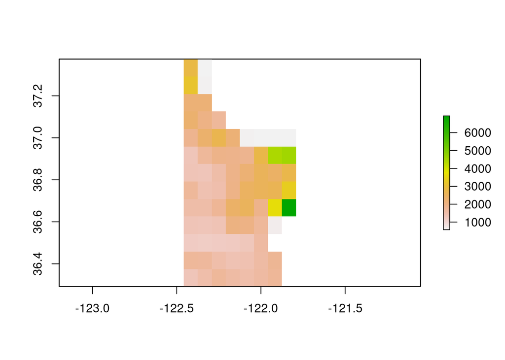

```r
plot(npp)
```

Plot one frame along with a reference map and sampling site(s).

```r
library(ggmap)
library(raster)
library(ggplot2)
library(viridis)
library(dplyr)

# Define the rectangle (bounding box) around the sampling site
bbox_rect <- data.frame(
  lon = as.vector(attributes(npp)$extent)[1:2],  # Longitude bounds
  lat = as.vector(attributes(npp)$extent)[3:4]  # Latitude bounds
)

# Load the raster file
npp <- raster("Monterrey_imagery_NPP/nppv_20161116.nc")

# Convert raster to dataframe for ggplot2
npp_df <- as.data.frame(npp, xy = TRUE, na.rm = TRUE)
colnames(npp_df) <- c("lon", "lat", "value")

# Define Sampling Site (M0)
sampling_site <- data.frame(lon = -121.901, lat = 36.835, label = "M0")

# Compute bounding box
centroids <- sampling_site  # Adjust if you have more sites
bbox <- make_bbox(centroids$lon + c(-0.5, 0.1),
                  centroids$lat + c(-0.5, 0.5))

# Register and fetch the map
register_stadiamaps(key = "f4aaa648-6137-4e34-a850-46c9821d7a6a")
map <- ggmap(get_stadiamap(bbox = bbox, zoom = 10, maptype = "stamen_terrain_background"))
```

```
## ℹ © Stadia Maps © Stamen Design © OpenMapTiles © OpenStreetMap contributors.
```

```r
# Combine the raster layer, background map, and sampling site
map <- map +
  geom_raster(data = npp_df, aes(x = lon, y = lat, fill = value), alpha = 0.5) +  # Semi-transparent raster
  scale_fill_viridis_c(option = "magma", na.value = "white") +  # Color scale for raster
  geom_point(data = sampling_site, aes(x = lon, y = lat), color = "red", size = 2) +  # Sampling site
  geom_polygon(data = bbox_rect, aes(x = lon, y = lat),
               fill = NA, color = "blue", size = 1)+
  geom_text(data = sampling_site, aes(x = lon, y = lat, label = label), vjust = -1, size = 3, fontface = "bold") +
  coord_equal() +
  theme_minimal() +
  labs(title = "NPP Raster Overlaid on Reference Map", fill = "NPP Value", x = "Longitude", y = "Latitude")
```

[output not shown]

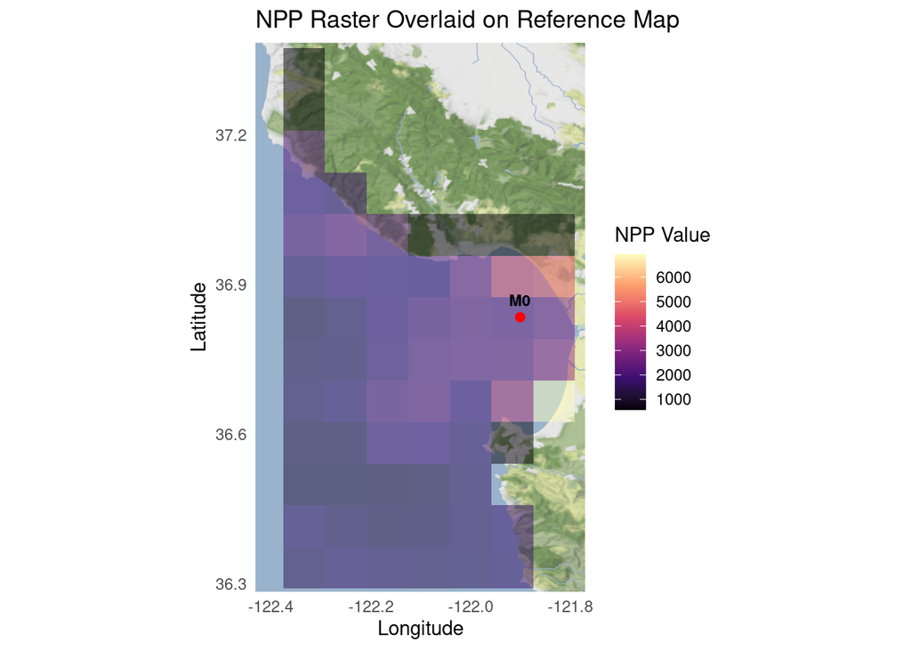

```r
map
```

Examine the possibility to extract grid values from a buffer zone. Define a buffer zone in case you want to use it.

[output not shown]

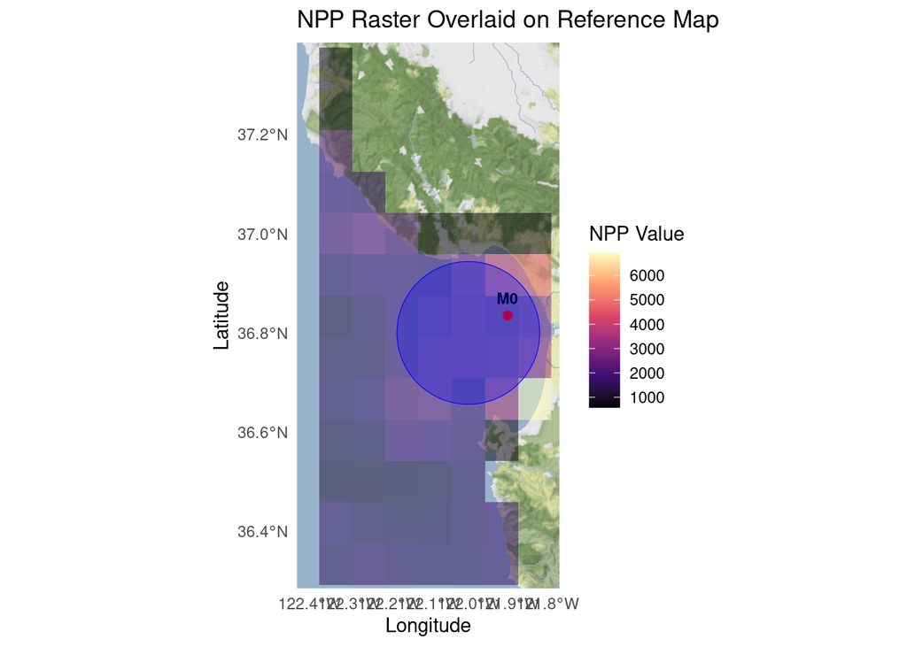

```r
# Load required packages
library(ggmap)
library(ggplot2)
library(sf)
buffer_meters <- 20000  # Radius in meters for extraction buffer

# Use original coordinates for extraction buffer or a nearby representative place
# coords2 <- coords
coords2 <- data.frame(lon = -122, lat = 36.8)

# Convert the coordinates into an sf point object
coords_sf <- st_as_sf(coords2, coords = c("lon", "lat"), crs = 4326)
# Transform to a projected CRS for proper distance measurement (meters)
coords_sf <- st_transform(coords_sf, crs = 3857)
# Create a circular buffer
buffer <- st_buffer(coords_sf, dist = buffer_meters)
# Transform back to lat/lon (WGS84) for plotting on ggmap
buffer <- st_transform(buffer, crs = 4326)

# Get the base map
map  +
  geom_sf(data = buffer, inherit.aes = FALSE, fill = "blue", alpha = 0.3, color = "blue")
```

Based on the buffer zone selected, extract grid values for each time frame. Extraction is done through `raster::extract` function. If argument `buffer` is used, all values contained within the buffer are returned, and if `fun` is provided in addition, all cell values are collapsed in one values (e.g., mean).

```r
output_file <- "cmems_mod_glo_bgc_my_0.083deg-lmtl_PT1D-i__v202411.npp.tsv"

# Get list of NetCDF files
files <- list.files(path = "./Monterrey_imagery_NPP/",
                    pattern = "nppv_.*\\.nc$",  # \ escapes the .
                    full.names = TRUE)         # Get full paths

# Function to extract the date from filenames
extract_date_from_filename <- function(filename) {
  match <- regexpr("nppv_(\\d{8})\\.nc$", basename(filename), perl = TRUE)
  if (match != -1) {
    date_str <- sub("nppv_(\\d{8})\\.nc$", "\\1", basename(filename))
    return(as.Date(date_str, format = "%Y%m%d"))  # Convert to Date format
  } else {
    return(NA)  # Return NA if no match is found
  }
}

# Initialize output list
output_list <- list()

# Loop through files
for (file in files) {
  date <- extract_date_from_filename(file)
  npp <- raster(file)  # Load raster
  value <- raster::extract(x = npp, y = coords2, buffer = buffer_meters, fun = mean, na.rm = T, small = FALSE, df = TRUE, weights = TRUE)[[2]]

  # Store results in a structured way
  output_list[[length(output_list) + 1]] <- data.frame(
    filename = basename(file),
    date = date,
    value = value
  )
}

# Combine results into a dataframe
output_df <- do.call(rbind, output_list)

# Save as TSV file
write.table(output_df, file = output_file, sep = "\t", row.names = FALSE, quote = FALSE)

head(output_df)
```

```
##           filename       date    value
## 1 nppv_20160926.nc 2016-09-26 3279.729
## 2 nppv_20160927.nc 2016-09-27 3689.217
## 3 nppv_20160928.nc 2016-09-28 3370.527
## 4 nppv_20160929.nc 2016-09-29 3229.986
## 5 nppv_20160930.nc 2016-09-30 4693.277
## 6 nppv_20161001.nc 2016-10-01 4383.606
```

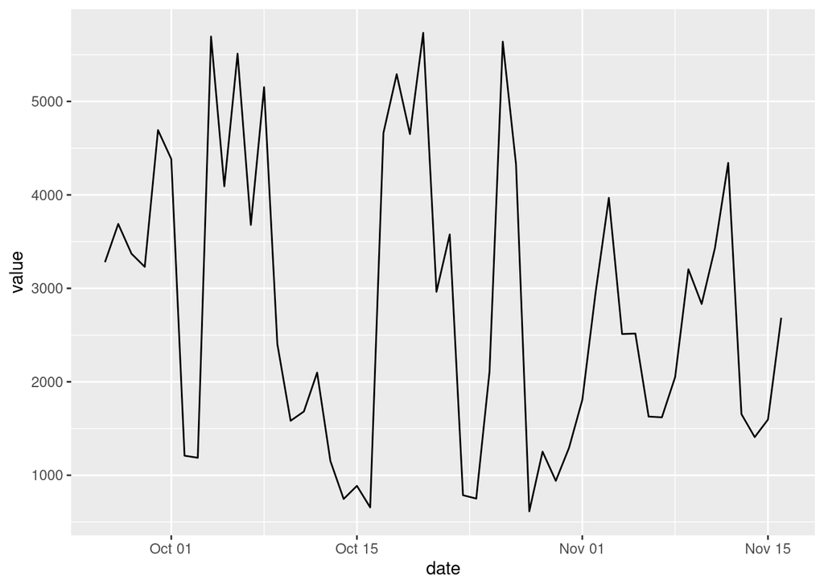

```r
output_df %>% ggplot(aes(date, value))+
  geom_line()
```

[^1]: Nowinski, B., Smith, C.B., Thomas, C.M., Esson, K., Marin, R., Preston, C.M., Birch, J.M., Scholin, C.A., Huntemann, M., Clum, A., Foster, B., Foster, B., Roux, S., Palaniappan, K., Varghese, N., Mukherjee, S., Reddy, T.B.K., Daum, C., Copeland, A., Chen, I.-M.A., Ivanova, N.N., Kyrpides, N.C., Glavina del Rio, T., Whitman, W.B., Kiene, R.P., Eloe-Fadrosh, E.A., and Moran, M.A. 2019. Microbial metagenomes and metatranscriptomes during a coastal phytoplankton bloom. Sci Data 6(1): 129. Nature Publishing Group. doi:10.1038/s41597-019-0132-4.